# What makes news, social media news

Benjamin Wedel Mathiasen, Bjarke Dahl Mogensen, Mikkel Mertz

# Introduction

Social media and in particular Facebook has become a part of the daily life during the last decade. Recent studies has shown that a growing part of the younger generations get the majority of their news from social media with Facebook as a popular choice (Reuters Institute Digital News Report 2012, p. 13). The increasing use of social media and the fact that a growing part of the younger generations get their news from social media might explain why an increasing proportion of Danes read news every day (Danske unges museums- og mediebrug, p. 55).  
But is the news on social media representative?  
Zuckerman (2013) finds that the media scene in general has become more focused on domestic news than previously and that news on social media to an even greater extent when considering the American news scene. The vast majority if not all social media monitor online behavior and use various algorithms to determine what specific stories to target the consumer. On Facebook, this means they control what news should pop up in the top of the newsfeed and thus gets most attention. This may ensure that people get to know what they want to know but not necessarily, what they need to know. Since there is a tendency for people to follow news closer to them more intensive and media tools at the same time expose people to specific stories, using this information, it seems to be a self-enforcing effect potentially indoctrinateing people in their own beliefs. In other words people only get exposed to stories supporting their beliefs.

The fact that beliefs in a sense are amplified within the closed system is referred to in the literature as “echo chambers” (Sunstein (2001)). The existence of echo chambers potentially narrows peoples’ view of the world. Because of various algorithms two almost identical persons potentially get very different results using a search engine as for example Google. This happens because of Google’s search algorithm, exposing persons to different results, pending on previous search history. While this makes searching online more efficient, vital information might get left out. Not everyone agrees that this is in fact the case and research made by The Media Insight Project found that in America 86% of people in the age group 18 to 34 years meet views different than their own on social media. This would make the potential problem smaller or insignificant (How Millennials Get News: Inside the Habits of America’s First Digital Generation. AP, University of Chicago and American Press Institute, march 2015).

The majority of Danish news media are represented both on an official website and a corresponding Facebook page - the Facebook page posting links to selected stories. However, far from all articles are posted on Facebook stating that selection occurs. But how is this selection made? Is it a random draw or is it a specific type of news qualifying for the Facebook page? In this specific setting, it might seem reasonable to assume that news media select the articles expected to be most popular thus in its very sense, subjecting people getting their news solely from Facebook, to a very selected subset of news - namely the news simular to previous stories getting a large amount of attention. It could be the case that a higher share of domestic than international articles are posted on their Facebook page since domestic articles may be more relatable than international articles, thus getting more views. If this is true it might be a significant factor in existens and creation of echo chambers. The aim of this paper is twofold:  
1) We wish to investigate what type of selection process, if any, is going on between the official website and Facebook page for a subsection of Danish media  
2) We wish to investigate if a specific type of articles ending up on Facebook catches most attention  
We investigate the first question by collecting articles published on DR’s and Politiken’s official website and look into what characterizes the articles making their way to Facebook. We do this, using a probit model and supervised learning models. We chose these specific media since they are two of the most online read media, thus hopefully catching a large fraction of the overall picture. For the second question, we consider the articles selected for Facebook and investigate whether it is a specific type of articles getting most attention on Facebook. We use the number of likes, comments and shares as a proxy for how many people getting exposed to the article.

# Data

The data used in this paper consists of articles scraped from DR and Politiken’s website and their corresponding Facebook pages, DR Nyheder and Politiken. We have scraped all articles from 18th of November 2014 and one year forward. We have chosen to scrape articles for one year to put an upper limit on the number of articles scraped, but still have a serious amount of articles to base our analysis on. A total of 74,966 articles were scrapped but after some revising of the data we ended up with a data frame containing 43,244 articles â 21,938 articles From DR, and 21,306 articles from Politiken.

## Scraping the websites

In order to scrape DR and Politiken’s website we used Google Chrome’s CSS selector extension -SelectorGadget. We scraped the media’s news archive for the article’s href link (article link) and date of the article release. When this information was obtained we used the article link to scrape the title and text of all articles. At last this information was merged together in one data frame by the articles link. The news section in which the articles were posted was obtained from the articles’ link. Some article links were directing to an error-page. These links were left out. Also, some of the articles’ text contained links to other articles and the belonging title. The links had the same CSS path as the article text, meaning the links could not be deselected while the text was selected. These links/titles were removed by substitution since they potentially could bias our results of the supervised learning models.  
For practical reasons the articles were scraped in several rounds. For DR each news section was scraped separately whereas for Politiken the articles were scraped by time periods. All the articles were merged together in a data frame at the end. Some articles appeared in more than one section. With a little inspection it was clear that these articles fitted into more than one section so we randomly removed duplicates.

## Scraping the Facebook pages

We scraped the medias’ Facebook pages âDR Nyhederâ and âPolitikenâ using Facebook’s API, which is convenient. We scraped information of the number of likes, comments and shares for the last 10,000 posts to make sure we had posts going back to 18th of November 2014.

## Websites and Facebook pages merged

The data from the medias’ websites and Facebook pages are merged together by the article link. Everything posted on the Facebook pages that is not posted on the websites, is discarded during the merge. If what systematically is left out, is a specific type of stories it can potentially bias our results. However, the removed stories were mainly videos from different sources and would not have made a difference since we only consider articles in the current setting. The new data frame contains all articles scraped from the websites and Facebook information about the articles posted on Facebook.

## Revising the data

The main purpose of this paper is to consider news articles, so from a subjective view, all sections that do not contain news articles are dropped. Also, sections which has its own Facebook page are dropped since articles from these sections mainly are posted on other Facebook pages than considered here. If we did not drop sections with a separate Facebook page our results would be bias, since these would see, to be left out of Facebook more frequently than in reality. The data has been trimmed from containing 36 sections to only contain 8 sections: Domestic, International, Politics, Money, Economics, Culture, Science, and The Magazine. The sections money and politics are only present at DR whilst economics and the magazine only are present at Politiken. The remainder sections are included in both media.

# From website to Facebook

The first thing to notice when considering the data is that a fairly small fraction of the articles getting posted on Facebook. 3,602 (16.4%) of DR’s articles and 3,479 (16.3%) of Politiken’s articles. As mentioned in the introduction we want to find out whether this selection seems to be random draw or if there is a certain type of selection. More precise, we want to find out whether this shift in news platform creates some kind of echo chambers - a situation in which information, ideas, or beliefs are amplified or reinforced by transmission and repetition inside an “enclosed” system. Our framework of analyzing and discussing this issue, is Figure 1 below. It shows the different interactions between media-consumers, media-producers and finally social media. Our starting point is to investigate the selection process of which articles from the websites that also gets shared on Facebook. We start by looking at descriptive figures and a binary-choice model. Later on we build a model to test the overall hypothesis, that the content of an article is a good predictor for whether an article is shared on Facebook or not.

**Figure 1 - Interrelationship between media consumers, media producers and social media**

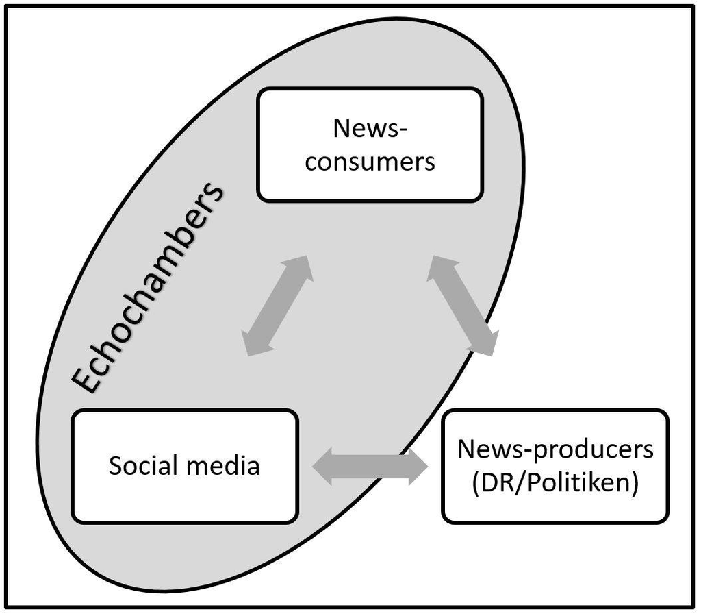

If we look at how these shares are distributed across sections as shown in Figure 2 we find that they differ quite a lot, also across the two media sources. At Politiken the most shared section is The Magazine. It is a part of Politiken’s premium content, so one could imagine that the high sharing-rate is because they have a special interest in promoting this particular content. On DR the section with lowest share-rate is international - only 13 % of the articles in this section are getting shared on Facebook. It is about the same rate on Politiken (12.7 %).

**Figure 2 - Share of articles from website getting posted on Facebook**

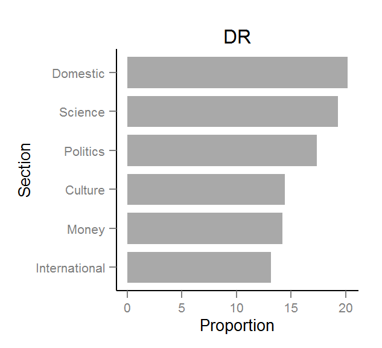

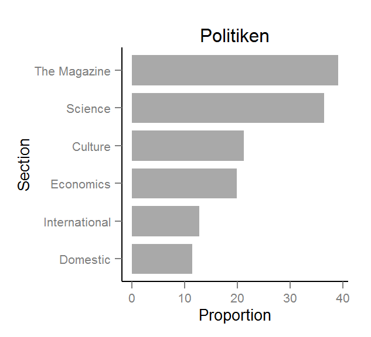

As Figure 2 shows there seems to be differences across sections in regards to what gets on Facebook. A simple binary choice model may shed light on whether there is significant correlation between the section and whether the article is shared on Facebook. The dependent (binary) variable in our binary choice model is whether or not the article is posted on Facebook. The explanatory variable is what section the article comes from. The model is constructed using the glm-function. The output from the model is reported in Table 1.

**Table 1**

|  | Estimate | Std. Error | z value | Pr(>\|z\|) |
| --- | --- | --- | --- | --- |
| (Intercept) | -1.13 | 0.01 | -77.87 | 0.00 |
| section2Domestic | 0.10 | 0.02 | 5.13 | 0.00 |
| section2Science | 0.36 | 0.03 | 10.34 | 0.00 |
| section2Politics | 0.19 | 0.03 | 6.70 | 0.00 |
| section2Culture | 0.26 | 0.02 | 10.97 | 0.00 |
| section2Money | 0.06 | 0.04 | 1.36 | 0.17 |
| section2Economics | 0.28 | 0.03 | 9.95 | 0.00 |
| section2The Magazine | 0.85 | 0.05 | 16.76 | 0.00 |

The reference-section is International news and as we see, a lot of the section-categories have a significantly different effect on the sharing-probability than the International section. With these estimates we cannot say anything about the marginal effect from one section or another, but the sign of the coefficients is directly interpretable. We see that all sections, except Money, have a significant, positive influence on the sharing-probability. There is no surprise here since it is interpretable as the averages. However it does underline our hypothesis that social media, in this context Facebook, has a larger focus than the official website on domestic news compared to foreign news.

## Supervised learning: Can we predict whether an article is shared on Facebook or not?

From the very simple binary choice model we now move to a more sophisticated method in our attempt to understand the underlying reasons for an article to be shared or not shared on Facebook. If we succeed in using the content of an article as a predictor for the sharing-probability, we are one step closer to finding out how a bias may look like.

We start out by creating a sub-sample of the total scrape. The amount of data is simply too big for the following algorithms to run on a normal laptop. We make a random draw of 4000 obs., which we will continue to work with below.  
With our sub-sample we now build an algorithm using RTextTool. We do this to investigate whether or not there is a clear selection process from the official website to Facebook. The following algorithm-design builds upon the nine steps described in the article RTextTools: A Supervised Learning Package for Text Classification by Jurka et al. (2013). However this process involves a series of choices that we will shortly walk through here. First of all, we need to prepare our data for the analysis. We do that by creating a document-featuring matrix. In that process we also change all words to lowercase letters, remove punctuations and separators, stemming the words and ignoring stop words. This gives us a total of 93,002 features or words.  
We choose to reduce the number of features, and we do this for two reasons: first - the amount of memory required performing training and classification of a model containing nearly 100,000 features and 4,000 unique observations exceed an ordinary laptops capacity. Second, we do not want rare words to deliver the majority of the leverage to the model. We remove all words that show op in less than 80 articles (2% of total), which gives us a total of 2,232 features.

**Table 2**

```
## ENSEMBLE SUMMARY
##
##        n-ENSEMBLE COVERAGE n-ENSEMBLE RECALL
## n >= 1                1.00              0.82
## n >= 2                1.00              0.82
## n >= 3                1.00              0.82
## n >= 4                1.00              0.82
## n >= 5                1.00              0.82
## n >= 6                0.96              0.83
## n >= 7                0.75              0.85
##
##
## ALGORITHM PERFORMANCE
##
##        SVM_PRECISION           SVM_RECALL           SVM_FSCORE
##                0.410                0.500                0.450
##       SLDA_PRECISION          SLDA_RECALL          SLDA_FSCORE
##                0.615                0.550                0.555
## LOGITBOOST_PRECISION    LOGITBOOST_RECALL    LOGITBOOST_FSCORE
##                0.410                0.500                0.450
##    FORESTS_PRECISION       FORESTS_RECALL       FORESTS_FSCORE
##                0.410                0.500                0.450
##     GLMNET_PRECISION        GLMNET_RECALL        GLMNET_FSCORE
##                0.620                0.510                0.480
##       TREE_PRECISION          TREE_RECALL          TREE_FSCORE
##                0.410                0.500                0.450
## MAXENTROPY_PRECISION    MAXENTROPY_RECALL    MAXENTROPY_FSCORE
##                0.555                0.560                0.555
```

In the table above Precision refers to how often the particular algorithm predicts correct. So in this context how often an article, that the algorithm predicts to be shared on Facebook, actually was shared on Facebook? On the other hand, Recall refers to the percentage of the articles shared on Facebook the algorithm correctly predicts to be shared on Facebook. The F-score is a weighted average of the above mentioned numbers.

It is clear that no single algorithm can make solid predictions alone. The largest F-scores is for SLDA and maximum entropy. Therefore, in line with the recommendation from Jurka et al., we now create an ensemble agreement to enhance labeling accuracy. The purpose of this exercise is to maximize the accuracy of our predictions. RTextTools include a function for this called create_ensembleSummary, but as we see above the result is also been printed when you use the summary(analytics)-function. To choose which ensemble to use is basically a trade-off between accuracy and coverage, the greater Recall-accuracy the lower coverage. Though, in this case there is 100 % coverage up until the 6th algorithm. For the first five algorithms, the Recall accuracy is 82 %, which is pretty good for such a high coverage.

Both the probit-model and the algorithms indicate that there is a system in the share-rate on Facebook depending on the section and the content of the article. If we found very low or no fit for both the probit-model and the algorithm, there would be no reason to think that there should be any difference in the kind of stories you will find at DR and Politiken’s website and the articles that they share on Facebook. But as mentioned, that is not the case.

One of the overall hypothesis in the Filter Bubble is, that our lives online, including social media, is narrower in the sense of confirming views and not making a representative representation of the world. This assignment sets out to investigate this hypothesis in a Danish context. We want to do that by comparing the foreign/domestic ratio of articles shared on Facebook and looking further on the characteristics on the articles, that have the greatest impact in terms of leveraged in our prediction model.

Now we take a closer look at the articles not shared on Facebook and with the highest ensemble probability (above the median). The articles regarding foreign stuff are heavily overrepresented in this sub-sample compared to the total dataset. 38 % of the articles in the sub-sample comes from the international section whereas this share only is 27.9 % in the total dataset. That is a clear sign, that our ensemble system finds a clear connection between the content of the articles and the sharing-probability.

# Are international news being left out

**Figure 3 - Article intensity by country**

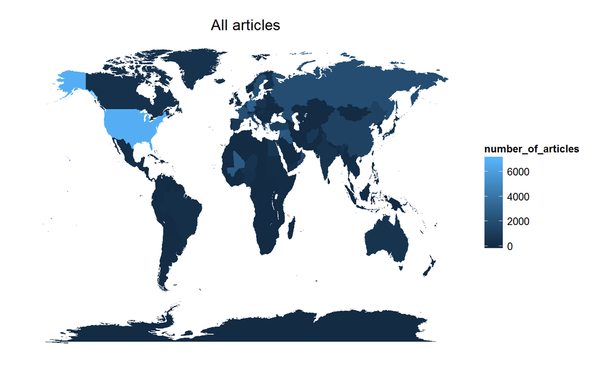

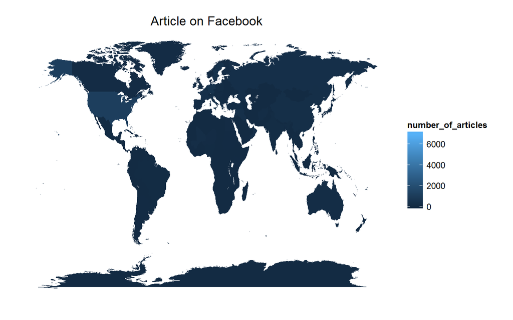

## What is viewed

**Figure 4 - Amount of average likes, comments and shares on Facebook**

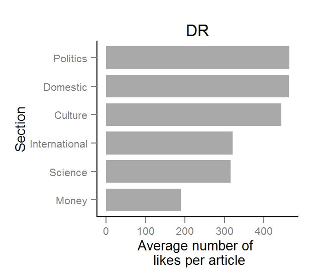

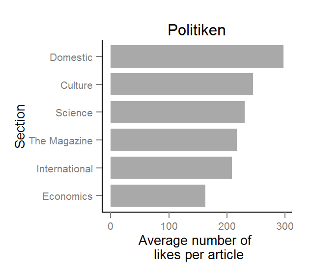

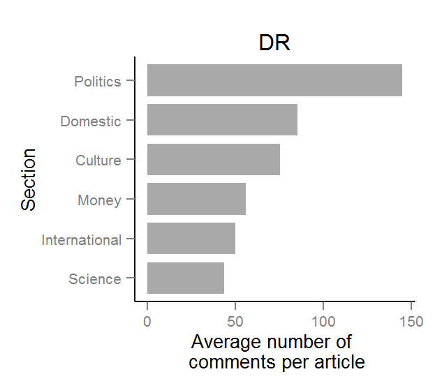

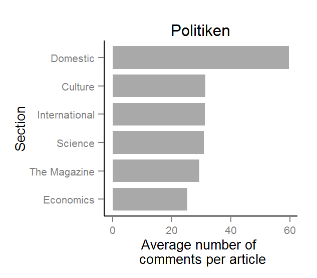

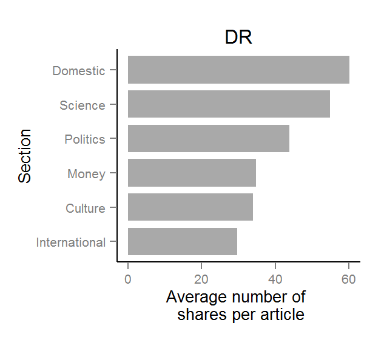

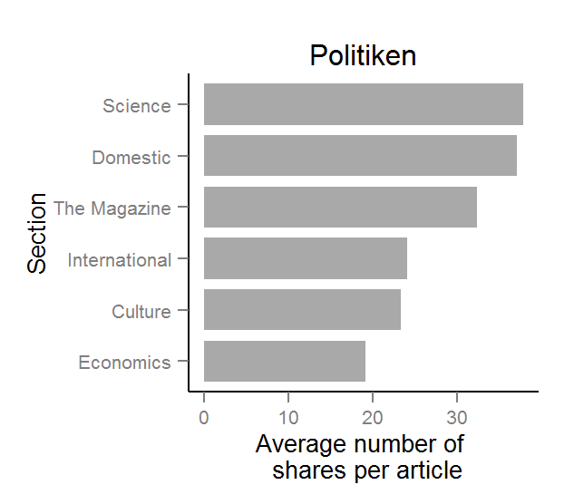

# Distance and exposure

**Figure 5 - Number of likes vs. distance**

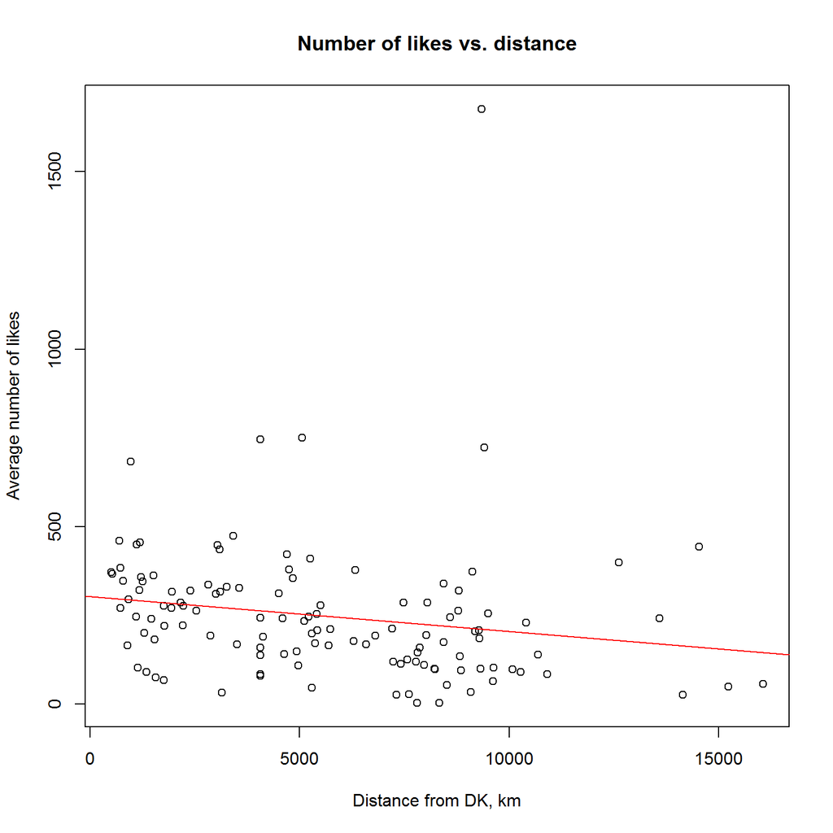

# Conclusion

# References

Reuters Institute. (2012). *Reuters Institute Digital News Report 2012: Tracking the Future of News*  
Dream. (2015). *Danske unges museums- og mediebrug*  
Zuckerman, Ethan. (2013). *Rewire, digital cosmopolitans in the age of connection*. New York: W. W. Norton & Company  
Pariser, Eli. (2011). *The Filter Bubble*. 1st edition, VIKING: Penguin Press  
Sunstein. (2001). - *Echo Chambers*. Princeton University Press  
Jurka, Timothy P; Collingwood, Loren; Boydstun, Amber E.; Grossman, Emiliano; Atteveldt, Wouter van. (2013). *RTextTools: A Supervised Learning Package for Text Classification*. The R Journal Vol. 5/1, June

# Appendix

## Number of articles from official website

```
##         region Articles
## 1          USA     6874
## 2      Germany     2943
## 3         Mali     2663
## 4        Syria     2639
## 5         Iraq     2471
## 6       France     1998
## 7       Sweden     1953
## 8       Russia     1946
## 9         Oman     1577
## 10      Greece     1472
## 11 Netherlands     1367
## 12       China     1344
## 13       Italy     1331
## 14      Turkey     1153
## 15      Israel      908
## 16 Afghanistan      769
## 17       Spain      692
## 18     Lebanon      662
## 19       Egypt      640
## 20       Japan      631
```

## Number of articles from Facebook page

```
##         region Articles
## 1          USA     1119
## 2      Germany      458
## 3       Sweden      401
## 4        Syria      368
## 5         Oman      321
## 6         Iraq      320
## 7       France      314
## 8       Russia      265
## 9  Netherlands      237
## 10       China      234
## 11       Italy      220
## 12      Greece      203
## 13        Mali      202
## 14      Turkey      165
## 15       Japan      127
## 16 Afghanistan      119
## 17   Australia      111
## 18       Spain      105
## 19      Israel       99
## 20       India       94
```